# Chapter 3: Attribute data operations

Yifei Liu

9/3/2019

```r
library(tidyverse)
library(dplyr)
library(sf)
library(raster)
library(dplyr)
library(ggthemes)
library(rcartocolor)
library(stringr) # for working with strings (pattern matching)
library(tidyr) # for unite() and separate()
library(spData)
```

## 3.1 Introduction

For vector data, sf dataset, this means operations such as subsetting and aggregation.

For Raster attributed data operations cover creating continuous and categorical raster alyers and extracting cell values from one layer and mltiple layers

## 3.2 Vector attibute manupulation

```r
methods(class = "sf")
```

```
##  [1] [                     [[<-                  $<-
##  [4] aggregate             anti_join             arrange
##  [7] as.data.frame         cbind                 coerce
## [10] dbDataType            dbWriteTable          distinct
## [13] extent                extract               filter
## [16] full_join             gather                group_by
## [19] group_map             group_split           identify
## [22] initialize            inner_join            left_join
## [25] mask                  merge                 mutate
## [28] nest                  plot                  print
## [31] raster                rasterize             rbind
## [34] rename                right_join            sample_frac
## [37] sample_n              select                semi_join
## [40] separate_rows         separate              show
## [43] slice                 slotsFromS3           spread
```

[output cut: 17 more lines]

```r
dim(world)
```

```
## [1] 177  11
```

```r
nrow(world)
```

```
## [1] 177
```

```r
ncol(world)
```

```
## [1] 11
```

```r
# remove its geometry

world_df <- st_drop_geometry(world)
class(world_df)
```

```
## [1] "tbl_df"     "tbl"        "data.frame"
```

### 3.2.1 Vector attibuted subsetting

### 3.2.2 Vector attibute aggregation

```r
aggregate(pop ~ continent, FUN = sum, data = world, na.rm = T)
```

```
##       continent        pop
## 1        Africa 1154946633
## 2          Asia 4311408059
## 3        Europe  669036256
## 4 North America  565028684
## 5       Oceania   37757833
## 6 South America  412060811
```

```r
aggregate(world["pop"], by = list(world$continent),
          FUN = sum, na.rm = T)
```

```
## Simple feature collection with 8 features and 2 fields
## Attribute-geometry relationship: 0 constant, 1 aggregate, 1 identity
## geometry type:  GEOMETRY
## dimension:      XY
## bbox:           xmin: -180 ymin: -90 xmax: 180 ymax: 83.64513
## epsg (SRID):    4326
## proj4string:    +proj=longlat +datum=WGS84 +no_defs
##                   Group.1        pop                       geometry
## 1                  Africa 1154946633 MULTIPOLYGON (((49.54352 -1...
## 2              Antarctica          0 MULTIPOLYGON (((-163.7129 -...
## 3                    Asia 4311408059 MULTIPOLYGON (((120.295 -10...
## 4                  Europe  669036256 MULTIPOLYGON (((-51.6578 4....
## 5           North America  565028684 MULTIPOLYGON (((-61.68 10.7...
## 6                 Oceania   37757833 MULTIPOLYGON (((169.6678 -4...
## 7 Seven seas (open ocean)          0 POLYGON ((68.935 -48.625, 6...
## 8           South America  412060811 MULTIPOLYGON (((-66.95992 -...
```

### 3.2.3 Vector attribute joining

use dplyr _join() functions

```r
world_coffee <- left_join(world, coffee_data)
class(world_coffee)
```

```
## [1] "sf"         "tbl_df"     "tbl"        "data.frame"
```

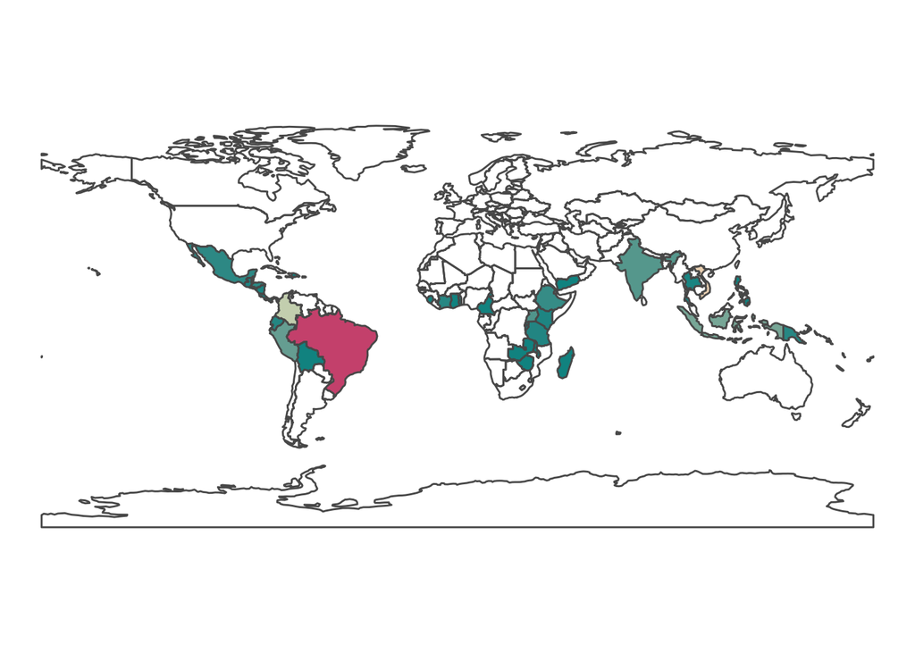

```r
ggplot(world_coffee) +
  geom_sf(aes(fill = coffee_production_2016)) +
  scale_fill_gradientn(colors = carto_pal(name = "TealRose", n = 7), na.value = NA) +
  theme_void() +
  theme(legend.position = "none")
```

```r
setdiff(coffee_data$name_long, world$name_long)
```

```
## [1] "Congo, Dem. Rep. of" "Others"
```

### 3.2.4 Creating attributes and removing spatial information

## 3.3 Manipulating raster objects

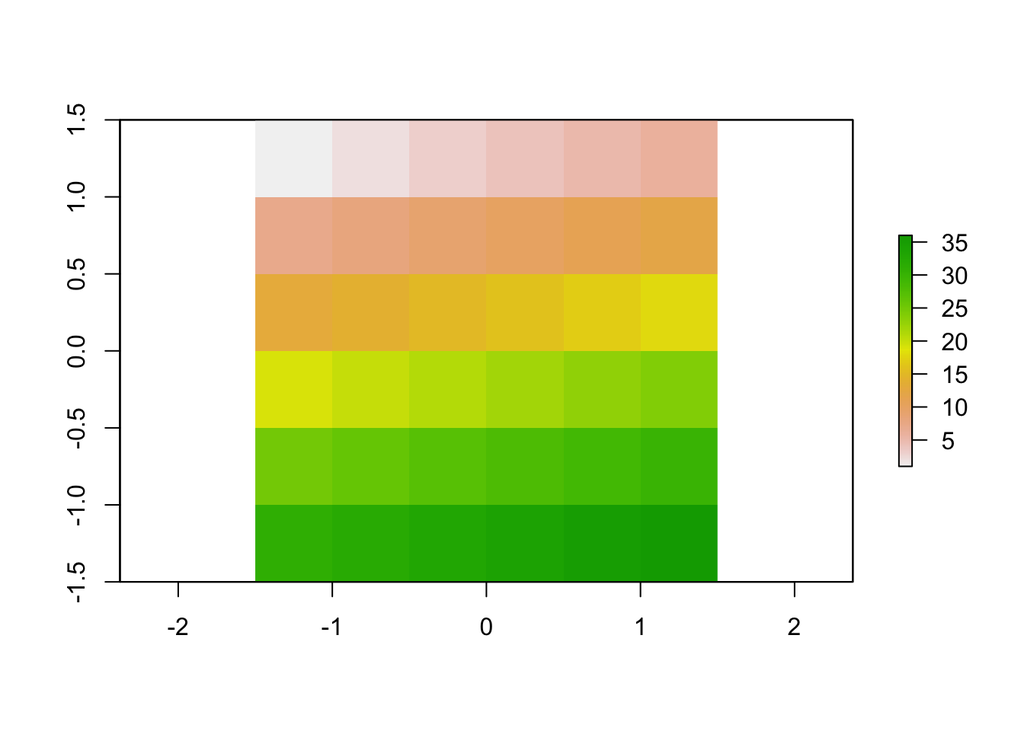

```r
elev <- raster(nrows = 6, ncols = 6, res = 0.5,
               xmn = -1.5, xmx = 1.5, ymn = -1.5, ymx = 1.5,
               vals = 1:36)

plot(elev)
```

```r
grain_order = c("clay", "silt", "sand")
grain_char <- sample(grain_order, 36, replace = T)
grain_fact <- factor(grain_char, levels = grain_order)

levels(grain)[[1]] <- cbind(levels(grain)[[1]], wetness = c("wet", "moist", "dry"))

levels(grain)
```

```
## [[1]]
##   ID VALUE wetness
## 1  1  clay     wet
## 2  2  silt   moist
## 3  3  sand     dry
```

```r
factorValues(grain, grain[c(1, 11, 35)])
```

```
##   VALUE wetness
## 1  sand     dry
## 2  silt   moist
## 3  clay     wet
```

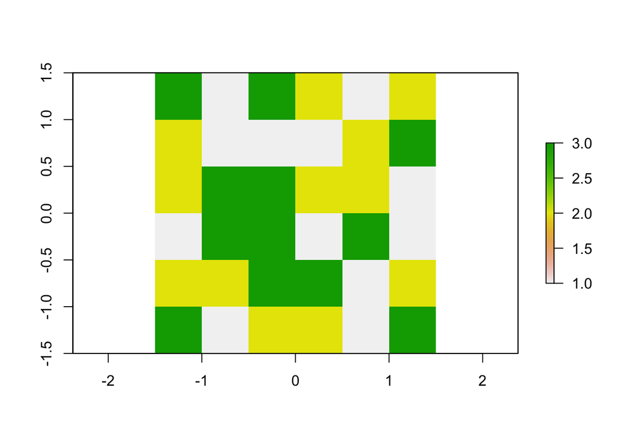

```r
plot(grain)
```

### 3.3.1 Raster subsetting

Raster subsetting is done with the abse R operator [, which accpets a varity of inputs:

- Row-column indexing
- cell IDs
- Coordiante
- Another spatial object

```r
elev[1,] # row1, column1
```

```
## [1] 1 2 3 4 5 6
```

```r
elev[1] #cell ID 1
```

```
## [1] 1
```

For multi-layered raster objects stack or brick, this will return the cell values for each layers.

```r
r_stack = stack(elev, grain)
names(r_stack) = c("elev", "grain")

# three ways to extrac a layer of a stack

raster::subset(r_stack, "grain")
```

```
## class      : RasterLayer
## dimensions : 6, 6, 36  (nrow, ncol, ncell)
## resolution : 0.5, 0.5  (x, y)
## extent     : -1.5, 1.5, -1.5, 1.5  (xmin, xmax, ymin, ymax)
## crs        : +proj=longlat +datum=WGS84 +ellps=WGS84 +towgs84=0,0,0
## source     : memory
## names      : grain
## values     : 1, 3  (min, max)
## attributes :
##  ID VALUE wetness
##   1  clay     wet
##   2  silt   moist
##   3  sand     dry
```

```r
r_stack[["elev"]]
```

```
## class      : RasterLayer
## dimensions : 6, 6, 36  (nrow, ncol, ncell)
## resolution : 0.5, 0.5  (x, y)
## extent     : -1.5, 1.5, -1.5, 1.5  (xmin, xmax, ymin, ymax)
## crs        : +proj=longlat +datum=WGS84 +ellps=WGS84 +towgs84=0,0,0
## source     : memory
## names      : elev
## values     : 1, 36  (min, max)
```

```r
r_stack$elev
```

```
## class      : RasterLayer
## dimensions : 6, 6, 36  (nrow, ncol, ncell)
## resolution : 0.5, 0.5  (x, y)
## extent     : -1.5, 1.5, -1.5, 1.5  (xmin, xmax, ymin, ymax)
## crs        : +proj=longlat +datum=WGS84 +ellps=WGS84 +towgs84=0,0,0
## source     : memory
## names      : elev
## values     : 1, 36  (min, max)
```

cell values can be modified by overwrting existing values

### 3.3.1 Summarizing raster objects

```r
# RasterLayer
cellStats(elev, sd)
```

```
## [1] 10.53565
```

```r
# Raster*

summary(brick(elev, grain))
```

```
##         layer.1 layer.2
## Min.       1.00       1
## 1st Qu.    9.75       1
## Median    18.50       2
## 3rd Qu.   27.25       3
## Max.      36.00       3
## NA's       0.00       0
```

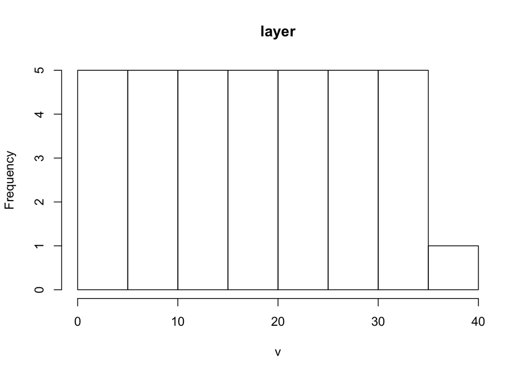

```r
hist(elev)
```

## 3.4 Exercise

```r
library(spData)
data(us_states)
data(us_states_df)
```

1. Create a new object called us_states_name that contains only the NAME column from the us_states object. What is the class of the new object and what makes it geographic?

```r
us_states_name <- us_states$NAME
class(us_states_name)
```

```
## [1] "character"
```

the new object *us_stat_name* is character object, and it is not geographic

2. Select columns from the us_states object which contain population data. Obtain the same result using a different command (bonus: try to find three ways of obtaining the same result). Hint: try to use helper functions, such as contains or starts_with from dplyr (see ?contains).

```r
us_states %>%
  dplyr::select(starts_with("total_"))
```

```
## Simple feature collection with 49 features and 2 fields
## geometry type:  MULTIPOLYGON
## dimension:      XY
## bbox:           xmin: -124.7042 ymin: 24.55868 xmax: -66.9824 ymax: 49.38436
## epsg (SRID):    4269
## proj4string:    +proj=longlat +datum=NAD83 +no_defs
## First 10 features:
##    total_pop_10 total_pop_15                       geometry
## 1       4712651      4830620 MULTIPOLYGON (((-88.20006 3...
## 2       6246816      6641928 MULTIPOLYGON (((-114.7196 3...
## 3       4887061      5278906 MULTIPOLYGON (((-109.0501 4...
## 4       3545837      3593222 MULTIPOLYGON (((-73.48731 4...
## 5      18511620     19645772 MULTIPOLYGON (((-81.81169 2...
## 6       9468815     10006693 MULTIPOLYGON (((-85.60516 3...
## 7       1526797      1616547 MULTIPOLYGON (((-116.916 45...
## 8       6417398      6568645 MULTIPOLYGON (((-87.52404 4...
## 9       2809329      2892987 MULTIPOLYGON (((-102.0517 4...
## 10      4429940      4625253 MULTIPOLYGON (((-92.01783 2...
```

3. Find all states with the following characteristics (bonus find and plot them):
- Belong to the Midwest region.
- Belong to the West region, have an area below 250,000 km2 and in 2015 a population greater than 5,000,000 residents (hint: you may need to use the function units::set_units() or as.numeric()).
- Belong to the South region, had an area larger than 150,000 km2 or a total population in 2015 larger than 7,000,000 residents.

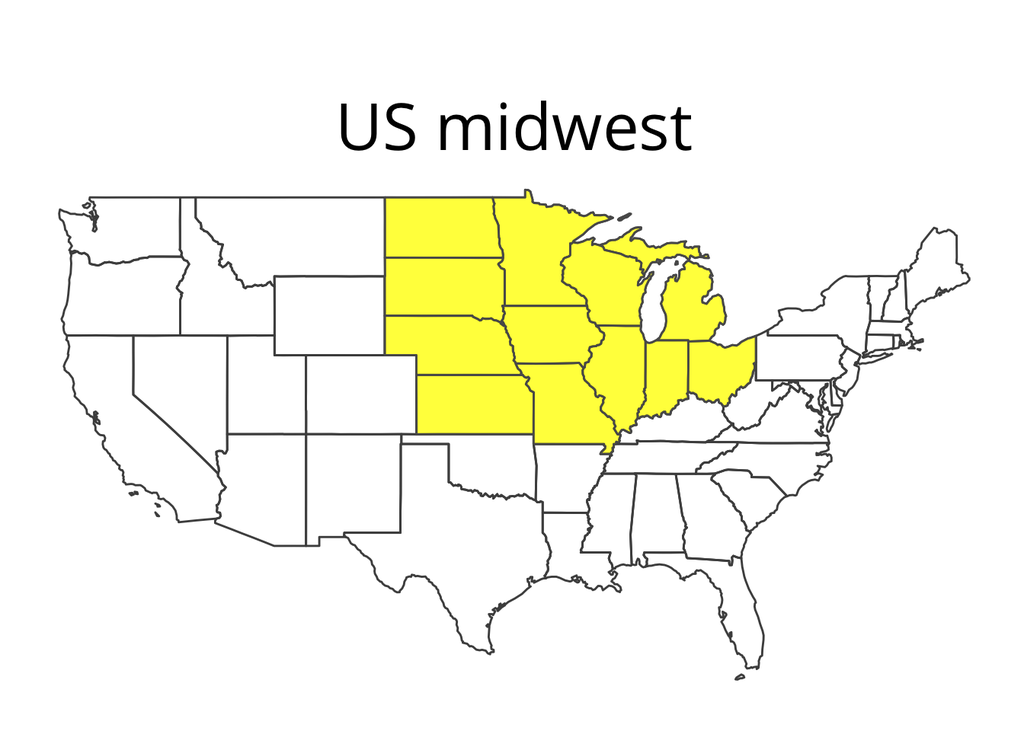

```r
mid_west <- us_states %>%
  filter(REGION == "Midwest")

ggplot() +
  geom_sf(data = us_states, fill = "NA", color = "grey30") +
  geom_sf(data = mid_west, fill = "yellow", alpha = 0.8) +
  theme_map(base_family = "Open Sans") +
  labs(title = "US midwest") +
  theme(plot.title = element_text(hjust = 0.5, size = 32, margin = margin(40, 0, 0,0)))
```

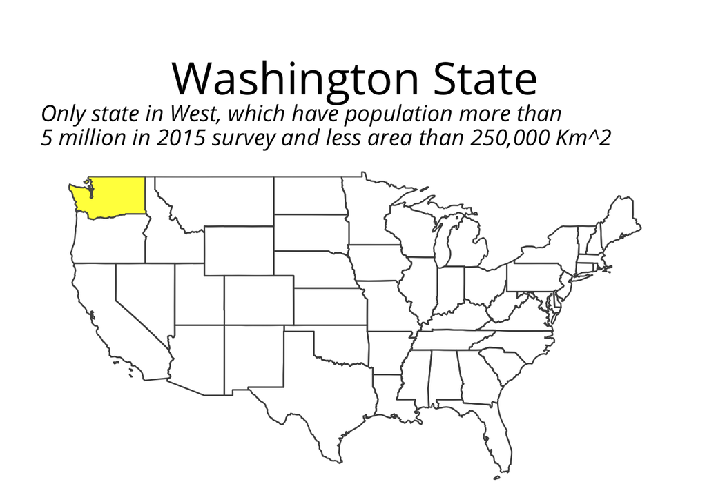

```r
west_region <- us_states %>%
  mutate(AREA = as.numeric(AREA)) %>%
  filter(AREA < 250000, REGION == "West", total_pop_15 > 5000000)

ggplot() +
  geom_sf(data = us_states, fill = "NA", color = "grey30") +
  geom_sf(data = west_region, fill = "yellow", alpha = 0.8) +
  theme_map(base_family = "Open Sans") +
  labs(title = "Washington State",
       subtitle = "Only state in West, which have population more than \n5 million in 2015 survey and less area than 250,000 Km^2") +
  theme(plot.title = element_text(hjust = 0.5, size = 32, margin = margin(40, 0, 0,0)),
        plot.subtitle = element_text(size = 16, face = "italic"))
```

4. What was the total population in 2015 in the us_states dataset? What was the minimum and maximum total population in 2015?
5. us_states_df has two more rows than us_states. How can you find them? (hint: try to use the dplyr::anti_join() function)

```r
setdiff(us_states_df$state, us_states$NAME)
```

```
## [1] "Alaska" "Hawaii"
```

Alaska and Hawaii not on the list. PS where is the puerto rico

14. Create a raster from scratch with nine rows and columns and a resolution of 0.5 decimal degrees (WGS84). Fill it with random numbers. Extract the values of the four corner cells.

```r
raster_ran <- raster(nrows = 9, ncols = 9, res = 0.5,
                     xmn = 0, ymn = 0, xmx = 4.5, ymx = 4.5,
                     vals = sample(1:81, size = 81, replace = F))
values(raster_ran)
```

```
##  [1] 37 74 31 55 33 66 62 78 11 71 30 65 69 47 19 43 34 73 26 42  8 81 18
## [24] 41 67 70 10 77 28 51  1 50 39 23  4 35 56 68  9 48 64 60 80 21 49 76
## [47] 53 52 45 61 36 57 75 59  3 38 58 63 40 22 72 29 54 24  2  6 46  5 14
## [70] 15 27 79 20 12 16 32 13  7 17 44 25
```

```r
res(raster_ran)
```

```
## [1] 0.5 0.5
```

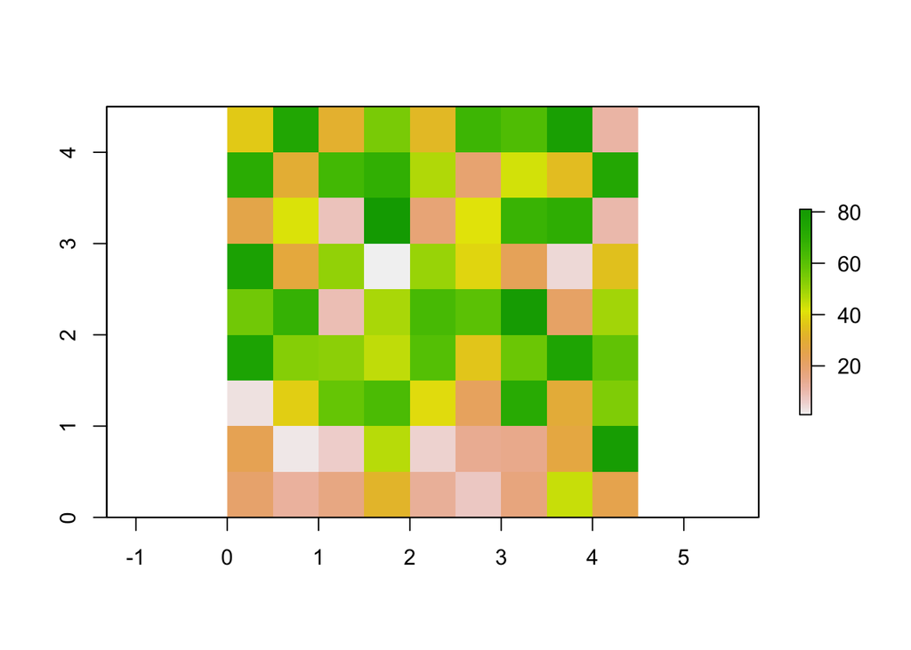

```r
plot(raster_ran)
```

```r
raster_ran[1,1]
```

```
## [1] 37
```

```r
raster_ran[1,9]
```

```
## [1] 11
```

```r
raster_ran[9,1]
```

```
## [1] 20
```

```r
raster_ran[9,9]
```

```
## [1] 25
```

15. What is the most common class of our example raster grain (hint: modal())?

```r
grain
```

```
## class      : RasterLayer
## dimensions : 6, 6, 36  (nrow, ncol, ncell)
## resolution : 0.5, 0.5  (x, y)
## extent     : -1.5, 1.5, -1.5, 1.5  (xmin, xmax, ymin, ymax)
## crs        : +proj=longlat +datum=WGS84 +ellps=WGS84 +towgs84=0,0,0
## source     : memory
## names      : layer
## values     : 1, 3  (min, max)
## attributes :
##  ID VALUE wetness
##   1  clay     wet
##   2  silt   moist
##   3  sand     dry
```

```r
cellStats(grain, modal)
```

```
## [1] 3
```

16. Plot the histogram and the boxplot of the data(dem, package = “RQGIS”) raster.

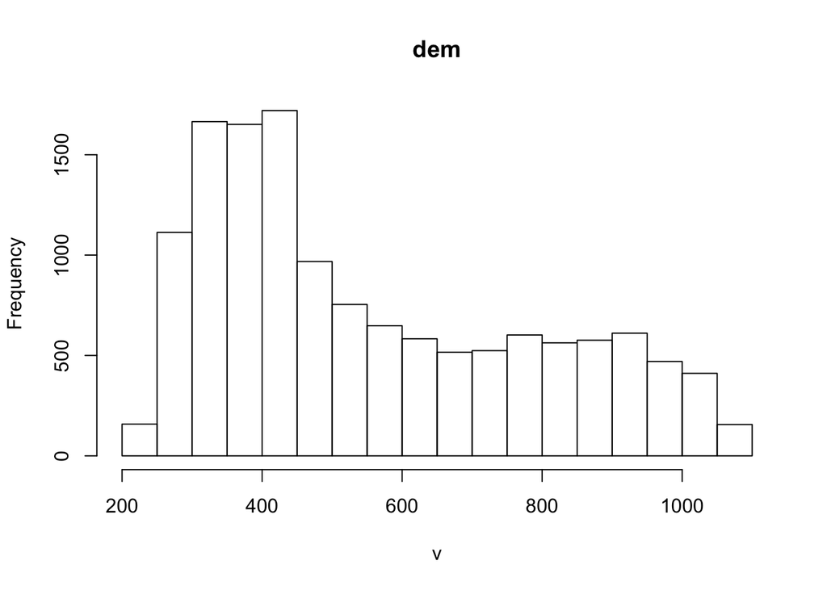

```r
data(dem, package = "RQGIS")

hist(dem)
```

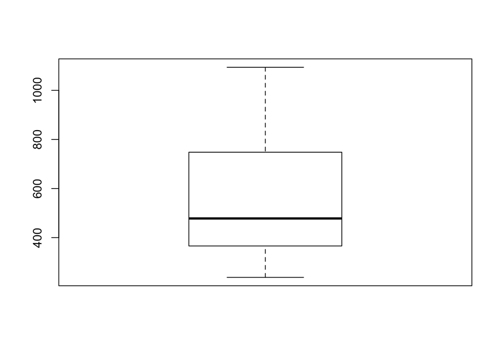

```r
boxplot(dem)
```